# PROJECT ANALISA KLASIFIKASI PINJAMAN UNTUK SEKTOR UMKM

Ika Nurfitriani

2022-08-23

## DESKRIPSI

Project ini adalah salah satu project yang terdapat di DQLab dan merupakan bagian dari proses pembelajaran saya di platform DQLab. DQLab adalah salah satu platform kursus data science di Indonesia. Mentor dalam project ini adalah Mr. Said Al Afghani, seorang Assistant Manager II di PT. Pegadaian (Persero).

Website DQLab: https://academy.dqlab.id/

## Pendahuluan

### Pengantar

Perusahaan Alembert merupakan perusahaan yang bergerak di bidang layanan pinjaman usaha bagi sektor UMKM. Karena adanya pandemik ini, perusahaan berusaha memberikan pelayanan berupa keringanan pinjaman bagi pelanggan yang disebut sebagai rekomendasi tindak lanjut. Pemberian rekomendasi tindak lanjut pada pelanggan ini didasari pada kriteria tertentu, dan perlu ditentukan faktor-faktor apa saja yang berpengaruh sehingga pelanggan mendapatkan treatment tertentu yang masuk dalam rekomendasi tindak lanjut program dari perusahaan.

**Tujuan Project**: Klasifikasi nasabah yang akan dimasukkan pada rekomendasi tindak lanjut. Pada kelas target rekomendasi tindak lanjut ini sendiri terdiri dari beberapa kelas seperti restrukturisasi dan angsuran biasa.

**Model**: Regresi multinomial.

**Referensi model (Ref)**: Kelas pada rekomendasi tindak lanjut yang memiliki banyak pelanggan.

**Data**: Data yang digunakan terdiri dari 1000 baris.

Tujuan Pembelajaran dari Project ini:

1. Memahami dasar-dasar sintak R untuk keperluan statistika dasar dan dasar-dasar machine learning.
2. Memberikan gambaran secara umum pemodelan dengan menggunakan R.

**Catatan** : Apabila ingin melakukan eksplorasi pada R yang terpasang pada komputer, dapat ditambahkan perintah **setwd(“path file tempat kamu bekerja”)** pada tiap baris pertama editor di R-Studio kamu.

### Membaca Data External

Hal yang pertama dilakukan adalah membaca dataset yang telah dipersiapkan. Dengan menggunakan fungsi bawaan R bacalah dataset yang berformat csv tersebut yang bernama “https://storage.googleapis.com/dqlab-dataset/project.csv”.

```r
data = read.csv("https://storage.googleapis.com/dqlab-dataset/project.csv")
```

### Inspeksi data

Setelah data berhasil di import, cobalah kamu untuk menginspeksi dataset dengan jalan

1. Melihat 6 baris pertama data tersebut, apa saja yang ditunjukkannya dan
2. Tampilkan tipe data dari setiap kolom.

```r
# Enam baris teratas data
head(data)
```

```
##   X           NAMA_NASABAH NOMOR_KONTRAK        DOMISILI         KARAKTER
## 1 0 YOLI SEPINA NAINGGOLAN             0     MASIH TETAP       KOOPERATIF
## 2 1         ERWIN NASUTION             1     MASIH TETAP TIDAK KOOPERATIF
## 3 2                  HUSIN             2     MASIH TETAP TIDAK KOOPERATIF
## 4 3              HARITSYAH             3 PINDAH PERMANEN       KOOPERATIF
## 5 4      HARIRI PANGGABEAN             4     MASIH TETAP TIDAK KOOPERATIF
## 6 5  JHON PREDDY HUTABARAT             5     MASIH TETAP       KOOPERATIF
##                PROFESI KONDISI_USAHA KONDISI_JAMINAN STATUS PRODUK       PYD
## 1     IBU RUMAH TANGGA             2            Baik      2      3  30000000
## 2              NELAYAN             3           Rusak      8      3  10000000
## 3              LAINNYA             3            Baik      8      3  60000000
## 4                  PNS             1           Rusak      7      3  90000000
## 5 WIRAUSAHA / PEDAGANG             1            Baik      8      3 150000000
## 6 WIRAUSAHA / PEDAGANG             1            Baik      7      3  40000000
##   TENOR      OSL KEWAJIBAN          KOLEKTIBILITAS COUNT_SURVEY
## 1    24 28750000   4896841 DALAM PENGAWASAN KHUSUS            1
## 2    12  2040693         0                   MACET            1
## 3    24        0         0                   MACET            1
## 4    18        0         0                   MACET            1
## 5    18 19844807         0                   MACET            1
## 6    36 27298726   2208516 DALAM PENGAWASAN KHUSUS            1
##   REKOMENDASI_TINDAK_LANJUT
## 1            Angsuran Biasa
## 2                 Penarikan
## 3                 Penarikan
## 4            Angsuran Biasa
## 5                 Penarikan
## 6           Restrukturisasi
```

```r
# Tampilkan tipe data setiap kolomnya
str(data)
```

```
## 'data.frame':    1000 obs. of  17 variables:
##  $ X                        : int  0 1 2 3 4 5 6 7 8 9 ...
##  $ NAMA_NASABAH             : chr  "YOLI SEPINA NAINGGOLAN" "ERWIN NASUTION" "HUSIN" "HARITSYAH" ...
##  $ NOMOR_KONTRAK            : int  0 1 2 3 4 5 6 7 8 9 ...
##  $ DOMISILI                 : chr  "MASIH TETAP" "MASIH TETAP" "MASIH TETAP" "PINDAH PERMANEN" ...
##  $ KARAKTER                 : chr  "KOOPERATIF" "TIDAK KOOPERATIF" "TIDAK KOOPERATIF" "KOOPERATIF" ...
##  $ PROFESI                  : chr  "IBU RUMAH TANGGA" "NELAYAN" "LAINNYA" "PNS" ...
##  $ KONDISI_USAHA            : int  2 3 3 1 1 1 3 2 2 3 ...
##  $ KONDISI_JAMINAN          : chr  "Baik" "Rusak" "Baik" "Rusak" ...
##  $ STATUS                   : int  2 8 8 7 8 7 7 7 7 3 ...
##  $ PRODUK                   : int  3 3 3 3 3 3 3 3 3 3 ...
##  $ PYD                      : int  30000000 10000000 60000000 90000000 150000000 40000000 60000000 7500000 45000000 50000000 ...
##  $ TENOR                    : int  24 12 24 18 18 36 36 4 24 36 ...
##  $ OSL                      : int  28750000 2040693 0 0 19844807 27298726 19999200 7500000 45000000 6944100 ...
##  $ KEWAJIBAN                : int  4896841 0 0 0 0 2208516 6946592 0 0 7730984 ...
##  $ KOLEKTIBILITAS           : chr  "DALAM PENGAWASAN KHUSUS" "MACET" "MACET" "MACET" ...
##  $ COUNT_SURVEY             : int  1 1 1 1 1 1 2 2 1 1 ...
##  $ REKOMENDASI_TINDAK_LANJUT: chr  "Angsuran Biasa" "Penarikan" "Penarikan" "Angsuran Biasa" ...
```

### Statistik Dekriptif data

Melalui R kita dapat menampilkan statistik deskriptif pada data yang dimiliki. Jika diinginkan lebih spesifik maka dapat dilakukan pada kolom tertentu pada tabel data yang kita punya. Tentunya kita dapat menggunakan accessor $ untuk memilih kolom yang diinginkan dari data.

```r
summary(data)
```

```
##        X         NAMA_NASABAH       NOMOR_KONTRAK     DOMISILI
##  Min.   :  0.0   Length:1000        Min.   :  0.0   Length:1000
##  1st Qu.:249.8   Class :character   1st Qu.:249.8   Class :character
##  Median :499.5   Mode  :character   Median :499.5   Mode  :character
##  Mean   :499.5                      Mean   :499.5
##  3rd Qu.:749.2                      3rd Qu.:749.2
##  Max.   :999.0                      Max.   :999.0
##    KARAKTER           PROFESI          KONDISI_USAHA   KONDISI_JAMINAN
##  Length:1000        Length:1000        Min.   :1.000   Length:1000
##  Class :character   Class :character   1st Qu.:2.000   Class :character
##  Mode  :character   Mode  :character   Median :2.000   Mode  :character
##                                        Mean   :2.273
##                                        3rd Qu.:3.000
##                                        Max.   :3.000
##      STATUS          PRODUK           PYD                TENOR
##  Min.   :2.000   Min.   : 3.00   Min.   :   500000   Min.   : 3.00
##  1st Qu.:3.000   1st Qu.: 3.00   1st Qu.:  8000000   1st Qu.:12.00
##  Median :7.000   Median : 3.00   Median : 15000000   Median :18.00
##  Mean   :5.379   Mean   :12.45   Mean   : 38537508   Mean   :20.75
##  3rd Qu.:7.000   3rd Qu.: 7.00   3rd Qu.: 50000000   3rd Qu.:24.00
##  Max.   :8.000   Max.   :77.00   Max.   :500000000   Max.   :48.00
##       OSL              KEWAJIBAN         KOLEKTIBILITAS      COUNT_SURVEY
##  Min.   :        0   Min.   :        0   Length:1000        Min.   :1.000
##  1st Qu.:  3999950   1st Qu.:   687487   Class :character   1st Qu.:1.000
##  Median :  8687350   Median :  2008974   Mode  :character   Median :1.000
##  Mean   : 26562373   Mean   :  5663981                      Mean   :1.036
##  3rd Qu.: 32082900   3rd Qu.:  4823198                      3rd Qu.:1.000
##  Max.   :440932336   Max.   :400900000                      Max.   :2.000
##  REKOMENDASI_TINDAK_LANJUT
##  Length:1000
##  Class :character
##  Mode  :character
##
##
##
```

### Menghapus Kolom

Pada data yang kamu miliki, sebenarnya kamu tidak memerlukan nama pelanggan untuk diberikan rekomendasi. Atau dengan kata lain penanda pelanggan untuk diberikan rekomendasi cukup dengan melihat no_kontrak pelanggan itu saja.

Tugas: Hapuslah kolom “X” dan nama nasabah pada data yang kamu miliki dan cetak kembali nama kolom yang tersedia pada data.

```r
data_reduce = data[-c(1,2)]
colnames(data_reduce)
```

```
##  [1] "NOMOR_KONTRAK"             "DOMISILI"
##  [3] "KARAKTER"                  "PROFESI"
##  [5] "KONDISI_USAHA"             "KONDISI_JAMINAN"
##  [7] "STATUS"                    "PRODUK"
##  [9] "PYD"                       "TENOR"
## [11] "OSL"                       "KEWAJIBAN"
## [13] "KOLEKTIBILITAS"            "COUNT_SURVEY"
## [15] "REKOMENDASI_TINDAK_LANJUT"
```

### Konversi Data

Seperti yang diketahui ketika data ditarik dari suatu sumber terkadang ada kondisi tipe data tidak dengan tepat direpresentasikan. Misalkan semua record/baris pada suatu kolom berisi seharusnya data numerik akan tetapi disajikan didalam suatu karakter angka.

R sendiri memiliki fungsi **sapply** yang dapat digunakan untuk mengkoversi tipe data. Dalam hal ini fungsi sapply menerima input/argumen fungsi berupa list, vector, atau data frame dan mengembalikan/menghasilkan output berupa vector atau matrix.

Cobalah untuk meninjau kembali kolom “PRODUK”, “PYD”, “TENOR”, dan “OSL” apakah perlu dikonversikan menjadi bertipe numerik atau tidak.

Jika tidak, kamu dapat menjawab dengan mengetikkan **FALSE** di code editor.

Tetapi, jika perlu dirubah maka ketikkanlah perintah berikut:

data_reduce[, 8:11] = sappy(data_reduce[, 8:11], as.numeric)

```r
FALSE
```

```
## [1] FALSE
```

### Pemilihan data kategori

```r
data_kategorik = data_reduce[, c("KONDISI_USAHA","KONDISI_JAMINAN","REKOMENDASI_TINDAK_LANJUT")]

data_reduce$REKOMENDASI_TINDAK_LANJUT = as.factor(data_reduce$REKOMENDASI_TINDAK_LANJUT)

chisq.test(data_kategorik$KONDISI_USAHA, data_kategorik$REKOMENDASI_TINDAK_LANJUT)
```

```
##
##  Pearson's Chi-squared test
##
## data:  data_kategorik$KONDISI_USAHA and data_kategorik$REKOMENDASI_TINDAK_LANJUT
## X-squared = 129.82, df = 6, p-value < 2.2e-16
```

```r
chisq.test(data_kategorik$KONDISI_JAMINAN, data_kategorik$REKOMENDASI_TINDAK_LANJUT)
```

```
##
##  Pearson's Chi-squared test
##
## data:  data_kategorik$KONDISI_JAMINAN and data_kategorik$REKOMENDASI_TINDAK_LANJUT
## X-squared = 162.87, df = 9, p-value < 2.2e-16
```

### Korelasi antar variabel data

Selain melihat hubungan pada data yang bersifat kategorikal, kita juga bisa melihat hubungan antar variabel numerikal. Ya. Kita akan menggunakan korelasi.

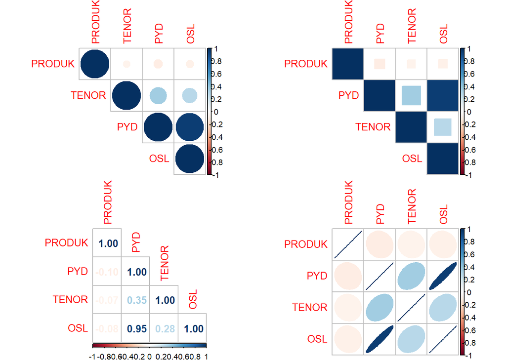

```r
library(corrplot)
library(ggcorrplot)
M = data_reduce[, 8:11]

# Library corrplot
# -- Pearson correlation
par(mfrow=c(2,2))
corrplot(cor(M), type="upper",order="hclust")
corrplot(cor(M), method="square",type="upper")
corrplot(cor(M), method="number",type="lower")
corrplot(cor(M), method="ellipse")
```

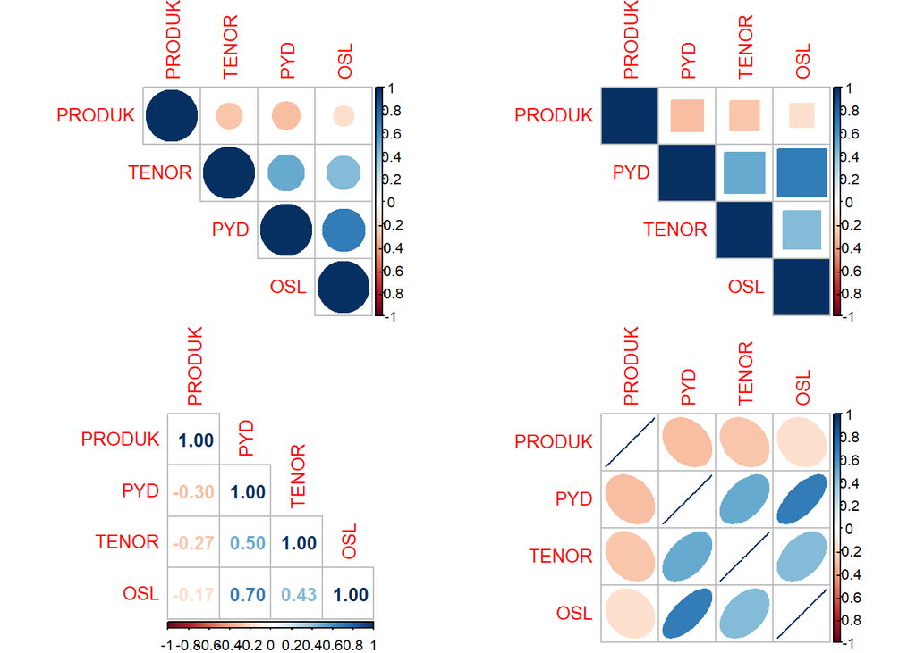

```r
# -- Kendall correlation
par(mfrow=c(2,2))
corrplot(cor(M, method="kendall"), type="upper",order="hclust")
corrplot(cor(M, method="kendall"), method="square",type="upper")
corrplot(cor(M, method="kendall"), method="number",type="lower")
corrplot(cor(M, method="kendall"), method="ellipse")
```

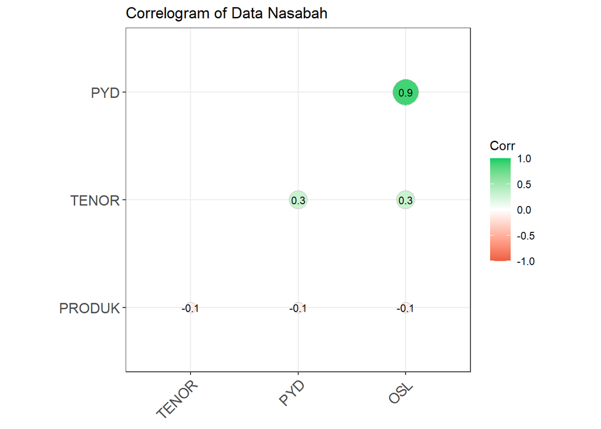

```r
# Library ggcorrplot
corr = round(cor(M), 1) # Pearson correlation
ggcorrplot(round(cor(M), 1),
          hc.order = TRUE,
          type = "lower",
          lab = TRUE,
          lab_size = 3,
          method = "circle",
          colors = c("tomato2","white","springgreen3"),
          title = "Correlogram of Data Nasabah",
          ggtheme = theme_bw)
```

Pada masing-masing sintak di atas tervisualisasikan beberapa variabel dalam kaitan hubungan antar satu variabel dengan variabel lainnya.

## Pemilihan Variable

### Pemilihan fitur/independent variabel/input

Dalam melakukan pemodelan tentu kita perlu meninjau variabel-variabel apa saja yang berpengaruh pada model kita, khususnya pada klasifikasi. Pada kesempatan ini kita menggunakan model Regresi Multinomial.

```r
colnames(data_reduce)
```

```
##  [1] "NOMOR_KONTRAK"             "DOMISILI"
##  [3] "KARAKTER"                  "PROFESI"
##  [5] "KONDISI_USAHA"             "KONDISI_JAMINAN"
##  [7] "STATUS"                    "PRODUK"
##  [9] "PYD"                       "TENOR"
## [11] "OSL"                       "KEWAJIBAN"
## [13] "KOLEKTIBILITAS"            "COUNT_SURVEY"
## [15] "REKOMENDASI_TINDAK_LANJUT"
```

```r
data_select =
data_reduce[,c("KARAKTER","KONDISI_USAHA","KONDISI_JAMINAN","STATUS","KEWAJIBAN","OSL","KOLEKTIBILITAS","REKOMENDASI_TINDAK_LANJUT")]
data_non_na = na.omit(data_select)
```

Jika pada data terdapat NA value, nilai tersebut dapat pula untuk dipangkas. Hapuslah nilai NA tersebut.

### Transformasi Data

Untuk memberikan performa model yang baik, maka pada data kita perlu dilakukan treatment tertentu, misalnya dilakukan scalling atau dilakukan pengelompokan data atau disebut juga bucketing.

```r
data_select_new = data_select
data_select_new$KEWAJIBAN = scale(data_select_new$KEWAJIBAN)[, 1]
data_select_new$OSL = scale(data_select_new$OSL)[, 1]
data_select_new$KEWAJIBAN = cut(data_select_new$KEWAJIBAN, breaks = c(-0.354107,5,15,30))
data_select_new$KEWAJIBAN = as.factor(data_select_new$KEWAJIBAN)
data_select_new$OSL = cut(data_select_new$OSL, breaks= c(-0.60383,3,10,15))
data_select_new$OSL = as.factor(data_select_new$OSL)
data_select_new = na.omit(data_select_new)
```

### Training Data

Sebelum masuk pada pemodelan, kita perlu memisahkan data kita menjadi training dan testing (ada pula yang membaginya menjadi training, testing, dan validasi).

Tujuan dari pemisahan data ini ialah untuk melihat kemampuan model kita untuk melakukan prediksi sebagaimana tujuan dari pemodelan kita.

```r
library(caret)
index = createDataPartition(data_select_new$REKOMENDASI_TINDAK_LANJUT, p= .95, list = FALSE)
train = data_select_new[index,]
test = data_select_new[-index,]
```

### Pemodelan/Modelling

Sekarang kita siap untuk masuk pada pemodelan.

Ingat bahwa kita menggunakan Model Regresi Multinomial, dimana kita perlu menentukan referensi dari kelas target.

Referensi kelas target ini ialah kelas yang memiliki jumlah anggota terbanyak.

```r
train2 = train
# Setting the reference
train2$REKOMENDASI_TINDAK_LANJUT = relevel(train2$REKOMENDASI_TINDAK_LANJUT, ref = "Angsuran Biasa")
#training the model
require(nnet)
# Training the multinomial model
multinom_model = multinom(REKOMENDASI_TINDAK_LANJUT ~ ., data = train2)
# Checking the model
summary(multinom_model)
```

```
## Call:
## multinom(formula = REKOMENDASI_TINDAK_LANJUT ~ ., data = train2)
##
## Coefficients:
##                  (Intercept) KARAKTERTIDAK KOOPERATIF KONDISI_USAHA
## Diskon Pelunasan   -3.262955                 1.776002    -0.7395132
## Penarikan          -7.478478                 3.637925     0.7217574
## Restrukturisasi    -4.127991                -2.260366     0.9795331
##                  KONDISI_JAMINANHilang KONDISI_JAMINANPindah Tangan
## Diskon Pelunasan           -24.6997691                  -27.1747309
## Penarikan                    0.8730593                    0.5546689
## Restrukturisasi              0.5009700                  -13.6878369
##                  KONDISI_JAMINANRusak    STATUS KEWAJIBAN(5,15]
## Diskon Pelunasan          -25.1217347 0.0969241               0
## Penarikan                  -1.0061029 0.1151513               0
## Restrukturisasi             0.1020155 0.3245591               0
##                  KEWAJIBAN(15,30]   OSL(3,10] OSL(10,15]
## Diskon Pelunasan        -3.929780   2.9912517          0
## Penarikan                1.166857 -25.9027242          0
## Restrukturisasi         27.321491   0.3635798          0
##                  KOLEKTIBILITASDIRAGUKAN KOLEKTIBILITASKURANG LANCAR
## Diskon Pelunasan               2.8501679                   0.2787231
## Penarikan                      4.4870441                   1.1655693
## Restrukturisasi               -0.1123873                  -0.1840878
##                  KOLEKTIBILITASLANCAR KOLEKTIBILITASMACET
## Diskon Pelunasan           0.08547222           0.5976027
## Penarikan                -30.57565318           1.8176430
## Restrukturisasi            0.83530149          -3.2573230
##
## Std. Errors:
##                  (Intercept) KARAKTERTIDAK KOOPERATIF KONDISI_USAHA
## Diskon Pelunasan   1.1067392                0.9037187     0.3823120
## Penarikan          1.2598373                0.6255479     0.3784048
## Restrukturisasi    0.3550675                0.7803456     0.1032816
##                  KONDISI_JAMINANHilang KONDISI_JAMINANPindah Tangan
## Diskon Pelunasan          2.421793e-12                 1.739812e-13
## Penarikan                 1.128468e+00                 6.684965e-01
## Restrukturisasi           1.178410e+00                 7.159447e-07
##                  KONDISI_JAMINANRusak     STATUS KEWAJIBAN(5,15]
## Diskon Pelunasan         4.845066e-12 0.14132584             NaN
## Penarikan                1.279423e+00 0.10445796             NaN
## Restrukturisasi          1.192534e+00 0.03728698               0
##                  KEWAJIBAN(15,30]    OSL(3,10] OSL(10,15]
## Diskon Pelunasan     3.889289e-15 1.045538e+00        NaN
## Penarikan                     NaN 9.841226e-14        NaN
## Restrukturisasi      3.962966e-13 6.311337e-01          0
##                  KOLEKTIBILITASDIRAGUKAN KOLEKTIBILITASKURANG LANCAR
## Diskon Pelunasan               0.9289846                   0.7417426
## Penarikan                      0.8955148                   0.6969970
## Restrukturisasi                0.6002134                   0.1934950
##                  KOLEKTIBILITASLANCAR KOLEKTIBILITASMACET
## Diskon Pelunasan         9.512842e-01           1.2231805
## Penarikan                2.098666e-14           0.7346257
## Restrukturisasi          2.142116e-01           1.0812796
##
## Residual Deviance: 1231.113
## AIC: 1309.113
```

```r
#converting the coefficients to odds by taking the exponential of the coefficients.
exp(coef(multinom_model))
```

```
##                   (Intercept) KARAKTERTIDAK KOOPERATIF KONDISI_USAHA
## Diskon Pelunasan 0.0382751405                5.9061988     0.4773462
## Penarikan        0.0005651168               38.0128741     2.0580469
## Restrukturisasi  0.0161152157                0.1043123     2.6632124
##                  KONDISI_JAMINANHilang KONDISI_JAMINANPindah Tangan
## Diskon Pelunasan          1.875109e-11                 1.578208e-12
## Penarikan                 2.394224e+00                 1.741364e+00
## Restrukturisasi           1.650321e+00                 1.136182e-06
##                  KONDISI_JAMINANRusak   STATUS KEWAJIBAN(5,15] KEWAJIBAN(15,30]
## Diskon Pelunasan         1.229615e-11 1.101777               1     1.964800e-02
## Penarikan                3.656411e-01 1.122043               1     3.211883e+00
## Restrukturisasi          1.107401e+00 1.383420               1     7.337917e+11
##                     OSL(3,10] OSL(10,15] KOLEKTIBILITASDIRAGUKAN
## Diskon Pelunasan 1.991059e+01          1               17.290685
## Penarikan        5.631056e-12          1               88.858401
## Restrukturisasi  1.438470e+00          1                0.893698
##                  KOLEKTIBILITASKURANG LANCAR KOLEKTIBILITASLANCAR
## Diskon Pelunasan                   1.3214414         1.089231e+00
## Penarikan                          3.2077485         5.262142e-14
## Restrukturisasi                    0.8318628         2.305509e+00
##                  KOLEKTIBILITASMACET
## Diskon Pelunasan           1.8177558
## Penarikan                  6.1573286
## Restrukturisasi            0.0384913
```

```r
head(round(fitted(multinom_model), 2))
```

```
##   Angsuran Biasa Diskon Pelunasan Penarikan Restrukturisasi
## 1           0.81             0.01      0.00            0.18
## 2           0.48             0.00      0.51            0.01
## 3           0.25             0.02      0.72            0.00
## 4           0.98             0.00      0.01            0.02
## 5           0.47             0.20      0.32            0.00
## 6           0.69             0.02      0.00            0.29
```

```r
# Predicting the values for train dataset
train2$ClassPredicted = predict(multinom_model, newdata = train2, "class")
train_prob = predict(multinom_model, newdata = train2, "probs")
df = train_prob
df$max=apply(df,1, max)
train2$score = df$max
test_prob = predict(multinom_model, newdata = test, "probs")
df2 = test_prob
df2$max=apply(df2,1, max)
tab_train = table(train2$REKOMENDASI_TINDAK_LANJUT, train2$ClassPredicted)
round((sum(diag(tab_train))/sum(tab_train))*100,4)
```

```
## [1] 68.2773
```

```r
test$ClassPredicted = predict(multinom_model, newdata = test, "class")
test$score = df2$max
tab_test = table(test$REKOMENDASI_TINDAK_LANJUT, test$ClassPredicted)
round((sum(diag(tab_test))/sum(tab_test))*100,4)
```

```
## [1] 75
```

Untuk keperluan tertentu, kita perlu mengetahui peluang dari tiap baris data (perwakilan dari pelanggan) untuk masuk pada kelas target tertentu.

Tujuannya ialah untuk melihat seberapa pengaruh model untuk melakukan klasifikasi. Selain itu bisa juga dari sudut pandang bisnis, dalam kasus real penentuan threshold pada nilai peluang juga dikaitkan dengan beberapa faktor, misalnya revenue pelanggan.

~~~~~~~~~~~~~~~~~~~~~~~~~~~~~~~~~~~~~~~~~~~~~~~~~~~~~~~~~~~~~~~~~~~~~~~~~~~~~~~~~~~~~~~~~~~~~~~~~~~~~~~~~~~~~~~ Tentang saya, silakan kunjungi:

- [rpubs.com/ikanurfitriani](https://rpubs.com/ikanurfitriani/)
- github.com/ikanurfitriani
- linkedin.com/in/ikanurfitriani
- medium.com/@ikanurfitriani